# Marovoay–Ankarafantsika: Household-Level and Long-Run Analysis

Author

BETSAKA project

Published

March 11, 2026

## 1 Panel Design: The Rotating-Panel Constraint

### 1.1 What the attrition data tell us

The Madagascar ROS panel is a **rotating panel**, not a strict re-interview panel. This is documented in detail by Chabé-Ferret et al. (2024, *Sci. Data* 11: 1085; doi:10.1038/s41597-024-03879-9):

- Annual attrition rate ≈ **15%**, cumulative ≈ **80% over 10 years**
- Attriting households are replaced by new randomly drawn ones to maintain n ≈ 500 per observatory per wave
- Attrition is **non-random**: the dominant cause is out-migration (65% of traceable attritors), which correlates with income and shock exposure
- Household identifiers (`j5`) are **not fully stable** across all years: six observatory-years had attrition rates >75% attributable to ID code reshuffles; the 2025 `j5` codes are from a new enumeration and carry no continuity with the 1995–2014 series

### 1.2 Implications for estimation strategy

**ImportantHousehold fixed effects are not appropriate here**

The standard panel DiD with **household fixed effects** (`| j5 + year`) would require the same households to be observed in both pre- and post-treatment periods. With 15% annual exit, only ~44% of 1998 households remain in 2003, and ~6% survive to 2014. Since treatment is assigned at the *site* level (not the household level), household FE absorbs within-household variance without providing the identification gains expected from a true balanced panel. The 2025 `j5` codes are entirely new and cannot be linked to any historical household.

**Valid approaches given a rotating panel:**

| Approach | Unit | FE structure | Requires HH tracking? |
| --- | --- | --- | --- |
| Repeated cross-sections DiD | Household | Site + year | No |
| Event study (RC) | Household | Site + year | No |
| Long-run 2×2 DiD | Household / site | Site + period | No |
| Synthetic control (SC/SDiD/gsynth) | Site-year | — | No |
| Spatial RDD (2025 cross-section) | Household | None | No |

All approaches below use one of these valid designs.

## 2 Panel Construction

```r
household_consolidated <- read_rds("data/household_consolidated.rds")

# ── Historical panel (1998–2014, 2005 Marovoay excluded) ─────────────────────
mk_income <- function(df) {
  df |>
    mutate(
      rev_riz  = coalesce(rev_riz,  0),
      rev_cu   = coalesce(rev_cu,   0),
      revel    = coalesce(revel,    0),
      revpeche = coalesce(revpeche, 0),
      revppal  = coalesce(revppal,  0),
      revsec   = coalesce(revsec,   0),
      revcou   = coalesce(revcou, revppal + revsec + rev_riz + rev_cu + revel + revpeche),
      revtot   = coalesce(revtot, revcou),
      rev_agri    = rev_riz + rev_cu + revel + revpeche,
      rev_nonagri = revppal + revsec
    )
}

# ── Historical panel: Marovoay 1999–2014 (2005 excluded) ────────────────────
panel_hist_maro <- household_consolidated |>
  filter(obs == "03", site_id %in% MARO_ALL,
         year %in% HIST_YEARS, !(year == 2005)) |>
  mk_income() |>
  mutate(
    treated_unit = site_id %in% MARO_TREATED,
    post         = year >= TREAT_YEAR,
    treatment    = as.integer(treated_unit & post),
    rel_time     = year - TREAT_YEAR
  ) |>
  # Winsorise at 99th percentile pooled across all site-years
  mutate(across(c(revtot, revcou, rev_agri, rev_nonagri),
                ~ pmin(.x, quantile(.x, 0.99, na.rm = TRUE)),
                .names = "{.col}_w")) |>
  mutate(across(ends_with("_w"), ~ log(.x + 1), .names = "ln_{.col}")) |>
  distinct(j5, year, .keep_all = TRUE)
# ── 2025 income (both observatories) via the standard pipeline ───────────────
# The historical snapshot (output/ref_incomes_snapshot.rds) ends at 2015.
# For 2025 we use compute_income_year() from utils/calc_incomes_all_years.R,
# which reads raw DTA files from data/ROS_MDG_microdata/2025/.
rev_2025_raw <- compute_income_year(2025) |>
  mutate(j5 = as.character(j5))

# ── 2025 wave — Marovoay (j0=3; fresh enumeration) ───────────────────────────
res_deb_25 <- read_dta("data/res_deb.dta") |>
  mutate(j5 = as.character(j5), j0 = as.character(as.numeric(j0)))

maro_25_ids <- res_deb_25 |>
  filter(j0 == "3") |>
  mutate(
    site_id = case_when(
      str_starts(str_to_lower(j4), "bepako")         ~ "031",
      str_starts(str_to_lower(j4), "madiromiongana") ~ "032",
      str_starts(str_to_lower(j4), "ampijoroa")      ~ "033",
      str_starts(str_to_lower(j4), "maroala")        ~ "034",
      TRUE ~ NA_character_
    ),
    obs = "03"
  ) |>
  select(j5, obs, site_id)

panel_2025_maro <- maro_25_ids |>
  left_join(rev_2025_raw, by = "j5") |>
  mutate(year = 2025) |>
  mk_income() |>
  mutate(
    treated_unit = site_id %in% MARO_TREATED,
    post = TRUE, treatment = as.integer(treated_unit),
    rel_time = 2025 - TREAT_YEAR
  ) |>
  mutate(across(c(revtot, revcou, rev_agri, rev_nonagri),
                ~ pmin(.x, quantile(.x, 0.99, na.rm = TRUE)),
                .names = "{.col}_w")) |>
  mutate(across(ends_with("_w"), ~ log(.x + 1), .names = "ln_{.col}"))
# ── 2025 wave — Alaotra (j0=21; control sites, fresh enumeration) ─────────────
# Site mapping: 211=Ambato (Avaradrano/Feramanga Atsimo/Mangabe),
#              212=Amparafa (Ambatoharanana/Ambodivoara/Analamiranga),
#              213=Morarano (Ambatomanga/Ambohidrony)
alaotra_25_ids <- res_deb_25 |>
  filter(j0 == "21") |>
  mutate(
    site_id = case_when(
      j4 %in% c("Avaradrano", "Feramanga Atsimo", "Mangabe")        ~ "211",
      j4 %in% c("Ambatoharanana", "Ambodivoara", "Analamiranga")   ~ "212",
      j4 %in% c("Ambatomanga", "Ambohidrony")                       ~ "213",
      TRUE ~ NA_character_
    ),
    obs = "21"
  ) |>
  select(j5, obs, site_id)

panel_2025_alaotra <- alaotra_25_ids |>
  filter(!is.na(site_id)) |>
  left_join(rev_2025_raw, by = "j5") |>
  mutate(year = 2025) |>
  mk_income() |>
  mutate(
    treated_unit = FALSE,
    post = TRUE, treatment = 0L,
    rel_time = 2025 - TREAT_YEAR
  ) |>
  mutate(across(c(revtot, revcou, rev_agri, rev_nonagri),
                ~ pmin(.x, quantile(.x, 0.99, na.rm = TRUE)),
                .names = "{.col}_w")) |>
  mutate(across(ends_with("_w"), ~ log(.x + 1), .names = "ln_{.col}"))
# ── Historical panel: Alaotra 1999–2014 (control only) ──────────────────────
panel_hist_alaotra <- household_consolidated |>
  filter(obs == "21", site_id %in% ALAOTRA_ALL, year %in% HIST_YEARS) |>
  mk_income() |>
  mutate(
    treated_unit = FALSE,
    post         = year >= TREAT_YEAR,
    treatment    = 0L,
    rel_time     = year - TREAT_YEAR
  ) |>
  mutate(across(c(revtot, revcou, rev_agri, rev_nonagri),
                ~ pmin(.x, quantile(.x, 0.99, na.rm = TRUE)),
                .names = "{.col}_w")) |>
  mutate(across(ends_with("_w"), ~ log(.x + 1), .names = "ln_{.col}")) |>
  distinct(j5, year, .keep_all = TRUE)
# ── Full RC DiD panel: Marovoay only (1999-2014 + 2025) ──────────────────────
# Historical Alaotra is NOT included here — parallel trends would need to be
# defended across two geographically distinct observatories for the medium run.
panel_maro_rc <- bind_rows(panel_hist_maro, panel_2025_maro) |>
  filter(!is.na(site_id))

# ── Long-run panel: Marovoay + Alaotra (1999-2002 pre vs 2025 post) ──────────
# Alaotra adds 3 control sites for the long-run comparison, boosting power.
# Valid because: (1) no PA in Alaotra until 2007 (temporary) / 2015 (permanent),
# so 1999-2002 pre-period is unaffected; (2) the Alaotra PA designation postdates
# the Ankarafantsika treatment by 4-12 years, so Alaotra is a clean control
# for the 2025 endpoint ONLY if we assume the Alaotra PA had no income effects
# by 2025 — a maintained assumption to be discussed in the text.
panel_lr_full <- bind_rows(
  panel_hist_maro  |> filter(year %in% PRE_YEARS),
  panel_hist_alaotra |> filter(year %in% PRE_YEARS),
  panel_2025_maro,
  panel_2025_alaotra
) |>
  filter(!is.na(site_id)) |>
  mutate(
    post_lr = as.integer(year == 2025),
    did_lr  = as.integer(treated_unit & post_lr)
  )

# Keep Marovoay-only long-run panel for comparison (original spec)
panel_lr2 <- bind_rows(
  panel_hist_maro |> filter(year %in% PRE_YEARS),
  panel_2025_maro
) |>
  filter(!is.na(site_id)) |>
  mutate(
    post_lr = as.integer(year == 2025),
    did_lr  = as.integer(treated_unit & post_lr)
  )

# ── Site-year aggregation (for gsynth comparison) ─────────────────────────────
panel_site_maro <- panel_hist_maro |>
  group_by(site_id, year, treated_unit, post, treatment) |>
  summarise(across(starts_with("ln_"), mean, na.rm = TRUE),
            n_hh = n(), .groups = "drop")
```

## 3 Attrition Diagnostics

### 3.1 Sample size per site per year

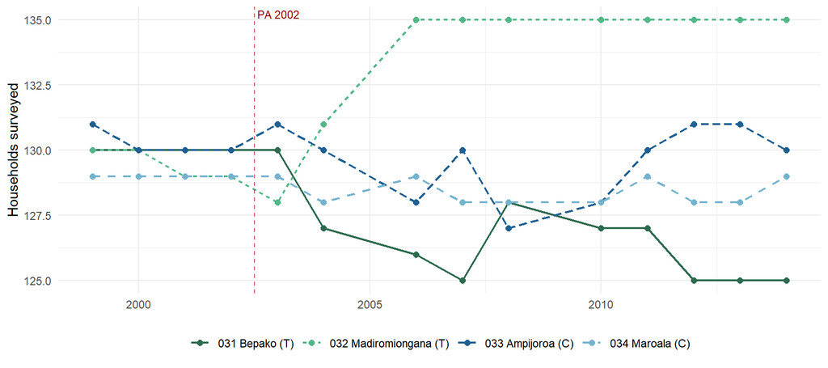

Households surveyed per site per year (Marovoay, historical panel)

```r
panel_hist_maro |>
  count(site_id, year) |>
  mutate(site_label = site_labels[site_id]) |>
  ggplot(aes(x = year, y = n, color = site_label, linetype = site_label)) +
  geom_line(linewidth = 0.8) +
  geom_point(size = 2) +
  geom_vline(xintercept = 2002.5, linetype = "dashed", color = "darkred", alpha = 0.6) +
  annotate("text", x = 2002.5, y = Inf, label = " PA 2002",
           hjust = 0, vjust = 1.3, size = 3, color = "darkred") +
  scale_color_manual(values = c("#2D6A4F","#52B788","#1E6091","#74B3CE")) +
  labs(x = NULL, y = "Households surveyed", color = NULL, linetype = NULL) +
  theme_minimal(base_size = 11) +
  theme(legend.position = "bottom")
```

### 3.2 Distribution of observation spells (1998–2014)

```r
spells <- panel_hist_maro |>
  count(j5, name = "n_waves")

spell_summary <- spells |>
  count(n_waves, name = "n_households") |>
  mutate(pct = round(100 * n_households / sum(n_households), 1),
         cum_pct = cumsum(pct))

gt(spell_summary) |>
  cols_label(n_waves = "Waves observed", n_households = "Households",
             pct = "%", cum_pct = "Cumulative %") |>
  tab_style(style = list(cell_text(weight = "bold"), cell_fill(color = "#DCDCDC")),
            locations = cells_column_labels()) |>
  tab_source_note(md(
    "Each `j5` code is counted across 1998–2014 (2005 excluded). Because `j5` codes
    are not fully stable across all years (Chabé-Ferret et al. 2024), this
    **overestimates** the share of single-observation households and **underestimates**
    true re-interview rates."
  ))
```

Distribution of household observation spells (Marovoay, 1998–2014)

| Waves observed | Households | % | Cumulative % |
| --- | --- | --- | --- |
| 1 | 213 | 17.9 | 17.9 |
| 2 | 161 | 13.6 | 31.5 |
| 3 | 107 | 9.0 | 40.5 |
| 4 | 106 | 8.9 | 49.4 |
| 5 | 65 | 5.5 | 54.9 |
| 6 | 68 | 5.7 | 60.6 |
| 7 | 28 | 2.4 | 63.0 |
| 8 | 65 | 5.5 | 68.5 |
| 9 | 42 | 3.5 | 72.0 |
| 10 | 58 | 4.9 | 76.9 |
| 11 | 54 | 4.5 | 81.4 |
| 12 | 31 | 2.6 | 84.0 |
| 13 | 40 | 3.4 | 87.4 |
| 14 | 149 | 12.6 | 100.0 |

Each `j5` code is counted across 1998–2014 (2005 excluded). Because `j5` codes are not fully stable across all years (Chabé-Ferret et al. 2024), this **overestimates** the share of single-observation households and **underestimates** true re-interview rates.

### 3.3 Differential attrition test

If attrition is correlated with treatment status, year-over-year sample composition may diverge between treated and control sites. We test this by comparing (a) annual sample counts and (b) mean household size over time across treated vs. control sites.

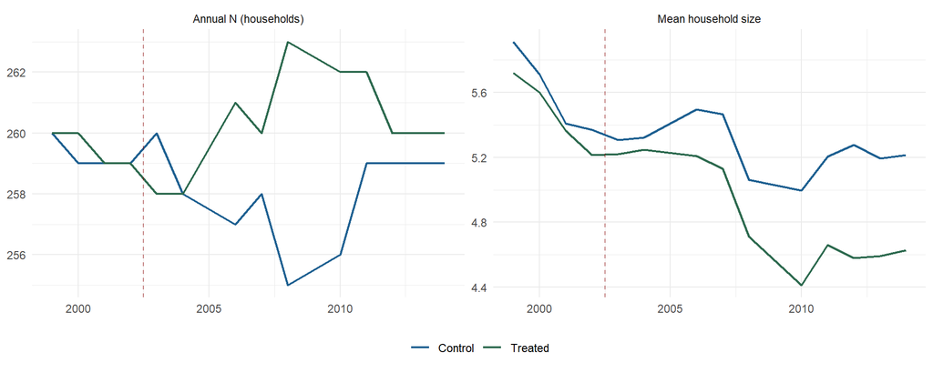

Year-over-year N and mean household size by treatment group

```r
panel_hist_maro |>
  mutate(Group = if_else(treated_unit, "Treated", "Control")) |>
  summarise(n = n(), mean_hh_size = mean(n_membres, na.rm = TRUE),
            .by = c(Group, year)) |>
  pivot_longer(c(n, mean_hh_size), names_to = "metric", values_to = "value") |>
  mutate(metric = recode(metric,
                         n = "Annual N (households)",
                         mean_hh_size = "Mean household size")) |>
  ggplot(aes(x = year, y = value, color = Group)) +
  geom_line(linewidth = 0.8) +
  geom_vline(xintercept = 2002.5, linetype = "dashed", color = "darkred", alpha = 0.5) +
  facet_wrap(~metric, scales = "free_y") +
  scale_color_manual(values = c("Treated" = "#2D6A4F", "Control" = "#1E6091")) +
  labs(x = NULL, y = NULL, color = NULL) +
  theme_minimal(base_size = 11) +
  theme(legend.position = "bottom")
```

```r
# Linear trend in household size post-treatment, by group
# If PA restriction caused differential migration, household size should diverge
fit_hh_size <- feols(
  n_membres ~ treatment + i(year, treated_unit, ref = 2002) | site_id + year,
  data    = panel_hist_maro,
  cluster = ~site_id
)
```

```
NOTE: 1 observation removed because of NA values (LHS: 1).
```

```
The variable 'year::2014:treated_unit' has been removed because of collinearity
(see $collin.var).
```

```r
# Simplified: just compare pre vs. post mean size by group
panel_hist_maro |>
  mutate(period = if_else(post, "Post-2002", "Pre-2002"),
         Group  = if_else(treated_unit, "Treated", "Control")) |>
  summarise(mean_size = round(mean(n_membres, na.rm = TRUE), 2),
            sd_size   = round(sd(n_membres,   na.rm = TRUE), 2),
            n         = n(),
            .by = c(Group, period)) |>
  arrange(Group, period) |>
  gt() |>
  cols_label(Group = "Group", period = "Period",
             mean_size = "Mean HH size", sd_size = "SD", n = "N obs") |>
  tab_style(style = list(cell_text(weight = "bold"), cell_fill(color = "#DCDCDC")),
            locations = cells_column_labels()) |>
  tab_source_note(md(
    "If mean household size diverges between treated and control groups after 2002,
    this suggests differential out-migration — a potential source of composition bias."
  ))
```

Test for differential trends in household size (composition check)

| Group | Period | Mean HH size | SD | N obs |
| --- | --- | --- | --- | --- |
| Control | Post-2002 | 5.25 | 2.50 | 2580 |
| Control | Pre-2002 | 5.60 | 2.67 | 1037 |
| Treated | Post-2002 | 4.84 | 2.25 | 2604 |
| Treated | Pre-2002 | 5.47 | 2.62 | 1038 |

If mean household size diverges between treated and control groups after 2002, this suggests differential out-migration — a potential source of composition bias.

## 4 Repeated Cross-Sections DiD

The repeated cross-sections (RC) DiD uses site + year fixed effects to identify the treatment effect. Since treatment is assigned at the site level, this is equivalent to the site-level TWFE but applied to household-level data — giving tighter standard errors by using the full within-site variation in outcomes, while still clustering at the site level to account for within-site correlation.

$$\ln y_{ist} = \alpha_s + \lambda_t + \delta \cdot D_{st} + \varepsilon_{ist}$$

where $D_{st} = \mathbf{1}[\text{site } s \in \text{Treated}] \times \mathbf{1}[t \geq 2003]$, $\alpha_s$ are site fixed effects, and $\lambda_t$ year fixed effects. Standard errors are clustered at the site level ($S = 4$).

### 4.1 Main specification

```r
# Historical panel only (excluding 2025 — different composition, instrument changes)
panel_rc_hist <- panel_hist_maro |>
  filter(year %in% HIST_YEARS)  # 1999–2014

fit_rc_revtot    <- feols(ln_revtot_w    ~ treatment | site_id + year,
                          data = panel_rc_hist, cluster = ~site_id)
fit_rc_revcou    <- feols(ln_revcou_w    ~ treatment | site_id + year,
                          data = panel_rc_hist, cluster = ~site_id)
fit_rc_agri      <- feols(ln_rev_agri_w  ~ treatment | site_id + year,
                          data = panel_rc_hist, cluster = ~site_id)
fit_rc_nonagri   <- feols(ln_rev_nonagri_w ~ treatment | site_id + year,
                          data = panel_rc_hist, cluster = ~site_id)

etable(fit_rc_revtot, fit_rc_revcou, fit_rc_agri, fit_rc_nonagri,
       headers = c("Total", "Coupled", "Agri", "Non-agri"),
       keep    = "treatment",
       se.below = TRUE,
       notes   = "Site + year FE. Clustered SE (4 clusters). 2005 excluded.")
```

```
                fit_rc_re.. fit_rc_re...1   fit_rc_agri   fit_rc_nonagri
                      Total       Coupled          Agri         Non-agri
Dependent Var.: ln_revtot_w   ln_revcou_w ln_rev_agri_w ln_rev_nonagri_w

treatment           0.0072        0.0349       -0.5293           0.2690
                   (0.1350)      (0.0704)      (0.5960)         (0.2215)
Fixed-Effects:  -----------   ----------- ------------- ----------------
site_id                 Yes           Yes           Yes              Yes
year                    Yes           Yes           Yes              Yes
_______________ ___________   ___________ _____________ ________________
S.E.: Clustered by: site_id   by: site_id   by: site_id      by: site_id
Observations          7,254         7,235         6,921            7,259
R2                  0.25985       0.08957       0.04780          0.02562
Within R2           6.34e-6       3.83e-5       0.00140          0.00030
---
Signif. codes: 0 '***' 0.001 '**' 0.01 '*' 0.05 '.' 0.1 ' ' 1
```

### 4.2 With household-size control

Household size may shift between treated and control sites if the PA restriction caused differential out-migration. Adding `n_membres` controls for this potential composition effect.

```r
fit_rc_cov <- feols(
  ln_revtot_w ~ treatment + n_membres | site_id + year,
  data = panel_rc_hist, cluster = ~site_id
)

etable(fit_rc_revtot, fit_rc_cov,
       headers = c("No controls", "+ HH size"),
       keep    = c("treatment", "n_membres"),
       se.below = TRUE,
       notes   = "Site + year FE. Clustered SE (4 clusters).")
```

```
                fit_rc_re..  fit_rc_cov
                No controls   + HH size
Dependent Var.: ln_revtot_w ln_revtot_w

treatment           0.0072    0.0372
                   (0.1350)  (0.1282)
n_membres                     0.1006***
                             (0.0064)
Fixed-Effects:  ----------- -----------
site_id                 Yes         Yes
year                    Yes         Yes
_______________ ___________ ___________
S.E.: Clustered by: site_id by: site_id
Observations          7,254       7,253
R2                  0.25985     0.36661
Within R2           6.34e-6     0.14432
---
Signif. codes: 0 '***' 0.001 '**' 0.01 '*' 0.05 '.' 0.1 ' ' 1
```

### 4.3 Event study (repeated cross-sections)

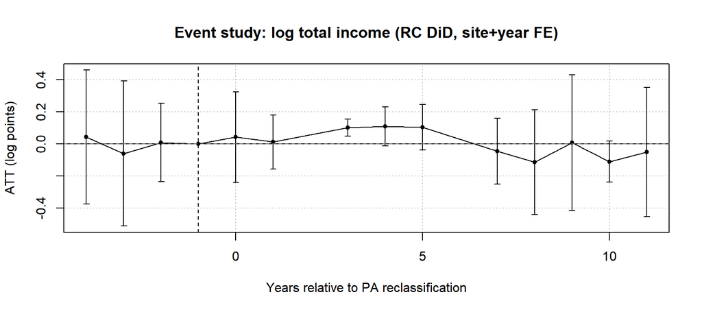

Event study — log total income (RC specification, site + year FE)

```r
panel_es <- panel_rc_hist |>
  mutate(rel_time = pmax(pmin(year - TREAT_YEAR, 11), -4))

fit_es_rc <- feols(
  ln_revtot_w ~ i(rel_time, treated_unit, ref = -1) | site_id + year,
  data    = panel_es,
  cluster = ~site_id
)
iplot(fit_es_rc,
      main  = "Event study: log total income (RC DiD, site+year FE)",
      xlab  = "Years relative to PA reclassification",
      ylab  = "ATT (log points)",
      pt.join = TRUE)
abline(h = 0, lty = 2, col = "grey40")
```

### 4.4 Exact permutation test (4 sites, 6 possible assignments)

With only 4 Marovoay sites and 2 treated, there are $\binom{4}{2} = 6$ possible assignments of 2 treated sites. We enumerate all of them exhaustively and compare the actual ATT to the permutation distribution. The minimum achievable two-sided p-value under this design is $2/6 \approx 0.33$ — a hard floor set by the number of units, not by the estimation method.

```r
# All C(4,2) = 6 possible treatment assignments
perm_grid <- combn(MARO_ALL, 2, simplify = FALSE)

perm_atts <- map_dbl(perm_grid, function(treat_sites) {
  d <- panel_rc_hist |>
    mutate(treatment = as.integer(site_id %in% treat_sites & post))
  tryCatch(
    coef(feols(ln_revtot_w ~ treatment | site_id + year,
               data = d, cluster = ~site_id,
               warn = FALSE, notes = FALSE))[["treatment"]],
    error = function(e) NA_real_
  )
})

actual_att_rc <- coef(fit_rc_revtot)[["treatment"]]
p_two_sided   <- mean(abs(perm_atts) >= abs(actual_att_rc), na.rm = TRUE)
p_one_sided   <- mean(perm_atts >= actual_att_rc, na.rm = TRUE)

# Table: all permutations
tibble(
  `Treated sites` = map_chr(perm_grid, paste, collapse = " + "),
  `ATT`           = round(perm_atts, 4),
  `Is actual`     = map_lgl(perm_grid, ~ setequal(.x, MARO_TREATED))
) |>
  arrange(desc(`Is actual`), ATT) |>
  gt() |>
  tab_style(
    style = list(cell_fill(color = "#D4EDDA"), cell_text(weight = "bold")),
    locations = cells_body(rows = `Is actual`)
  ) |>
  tab_style(style = list(cell_text(weight = "bold"), cell_fill(color = "#DCDCDC")),
            locations = cells_column_labels()) |>
  tab_footnote(
    paste0("Two-sided p = ", round(p_two_sided, 3),
           " (min achievable = 0.333). One-sided p = ", round(p_one_sided, 3), "."),
    locations = cells_column_labels(ATT)
  ) |>
  tab_source_note(md("Green row = actual treatment assignment. All 6 possible assignments enumerated."))
```

Exact permutation test — RC DiD, log total income

| Treated sites | ATT<sup>1</sup> | Is actual |
| --- | --- | --- |
| 031 + 032 | 0.0072 | TRUE |
| 031 + 033 | -0.2268 | FALSE |
| 032 + 033 | -0.0558 | FALSE |
| 033 + 034 | -0.0072 | FALSE |
| 031 + 034 | 0.0558 | FALSE |
| 032 + 034 | 0.2268 | FALSE |

<sup>1</sup> Two-sided p = 1 (min achievable = 0.333). One-sided p = 0.5.  
Green row = actual treatment assignment. All 6 possible assignments enumerated.

## 5 Long-Run 2×2 DiD: Pre-treatment vs. 2025

The 2025 BETSAKA survey provides a **23-year post-treatment observation**. A long-run DiD comparing the pre-treatment period (1999–2002) to the 2025 wave bypasses all intermediate panel-gap issues: it requires no tracking and no interpolation across the 2015–2024 gap. The estimand is the compound ATT accumulating both the original 2002 Ankarafantsika reclassification and the 2015 boundary extension.

**WarningWhat the long-run DiD measures**

The 2025 endline reflects **23 years of cumulative treatment**, including both the 2002 PA designation and the 2015 boundary extension (Décret n° 2015-730), which further expanded the park perimeter. The long-run ATT cannot be attributed to either event in isolation. Interpret as the total long-run impact of the PA regime as of 2025.

**NoteAlaotra controls: validity and timing**

The Alaotra Lac observatory sites (211 Ambato, 212 Amparafa, 213 Morarano) serve as additional control sites in the extended long-run specification. Alaotra is subject to a distinct PA process: a **temporary protection decree (2007)** followed by **permanent national protection (2015)**. Two implications for validity:

### 5.1 Site-level comparison

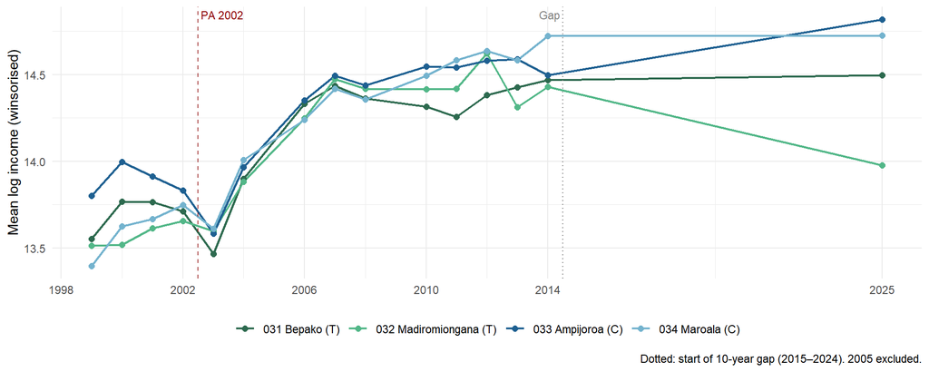

Income trajectories with 2025 endpoint — treated vs. control sites

```r
panel_site_maro |>
  bind_rows(
    panel_2025_maro |>
      group_by(site_id, year, treated_unit, post, treatment) |>
      summarise(across(starts_with("ln_"), mean, na.rm = TRUE),
                n_hh = n(), .groups = "drop")
  ) |>
  filter(year >= 1998) |>
  mutate(
    site_label = site_labels[site_id],
    Group = if_else(treated_unit, "Treated (031/032)", "Control (033/034)")
  ) |>
  ggplot(aes(x = year, y = ln_revtot_w, color = site_label, group = site_label)) +
  geom_line(linewidth = 0.8) +
  geom_point(size = 2) +
  geom_vline(xintercept = 2002.5, linetype = "dashed", color = "darkred", alpha = 0.7) +
  geom_vline(xintercept = 2014.5, linetype = "dotted", color = "grey50") +
  annotate("text", x = 2002.5, y = Inf, label = " PA 2002",
           hjust = 0, vjust = 1.4, size = 3, color = "darkred") +
  annotate("text", x = 2014.5, y = Inf, label = " Gap ",
           hjust = 1, vjust = 1.4, size = 3, color = "grey50") +
  scale_color_manual(values = c("#2D6A4F","#52B788","#1E6091","#74B3CE")) +
  scale_x_continuous(breaks = c(seq(1998, 2014, 4), 2025)) +
  labs(x = NULL, y = "Mean log income (winsorised)", color = NULL,
       caption = "Dotted: start of 10-year gap (2015–2024). 2005 excluded.") +
  theme_minimal(base_size = 11) +
  theme(legend.position = "bottom")
```

### 5.2 Long-run DiD regression (household-level, site + period FE)

Two specifications are reported side-by-side:

- **Marovoay only (4 sites)**: cleanest control group, tightest geographic comparability; minimum permutation p = 0.333.
- **Marovoay + Alaotra (7 sites)**: adds 3 Alaotra control sites, improving power; minimum permutation p = 0.095 with $\binom{7}{2} = 21$ allocations. Validity requires Alaotra incomes not to have been differentially affected by the 2015 Alaotra PA (see callout above).

```r
# Marovoay-only specification (4 sites)
fit_lr <- feols(
  ln_revtot_w ~ did_lr | site_id + post_lr,
  data    = panel_lr2,
  cluster = ~site_id
)
fit_lr_agri <- feols(
  ln_rev_agri_w ~ did_lr | site_id + post_lr,
  data    = panel_lr2, cluster = ~site_id
)
fit_lr_nonagri <- feols(
  ln_rev_nonagri_w ~ did_lr | site_id + post_lr,
  data    = panel_lr2, cluster = ~site_id
)

# Extended specification: Marovoay + Alaotra (7 sites)
fit_lr_ext <- feols(
  ln_revtot_w ~ did_lr | site_id + post_lr,
  data    = panel_lr_full,
  cluster = ~site_id
)
fit_lr_ext_agri <- feols(
  ln_rev_agri_w ~ did_lr | site_id + post_lr,
  data    = panel_lr_full, cluster = ~site_id
)
fit_lr_ext_nonagri <- feols(
  ln_rev_nonagri_w ~ did_lr | site_id + post_lr,
  data    = panel_lr_full, cluster = ~site_id
)

etable(
  fit_lr, fit_lr_agri, fit_lr_nonagri,
  fit_lr_ext, fit_lr_ext_agri, fit_lr_ext_nonagri,
  headers = c("Total (Maro)", "Agri (Maro)", "Non-agri (Maro)",
              "Total (Maro+Al)", "Agri (Maro+Al)", "Non-agri (Maro+Al)"),
  keep    = "did_lr",
  se.below = TRUE,
  notes   = paste0(
    "Pre-period: ", min(PRE_YEARS), "–", max(PRE_YEARS),
    ". Post-period: 2025. Site + period FE. ",
    "Maro: 4 clusters; Maro+Alaotra: 7 clusters."
  ))
```

```
                      fit_lr   fit_lr_agri   fit_lr_nonagri      fit_lr_ext
                Total (Maro)   Agri (Maro)  Non-agri (Maro) Total (Maro+Al)
Dependent Var.:  ln_revtot_w ln_rev_agri_w ln_rev_nonagri_w     ln_revtot_w

did_lr              -0.4249        0.0343            1.419         -0.7533*
                    (0.1779)      (0.7190)          (1.014)        (0.2169)
Fixed-Effects:   ----------- ------------- ----------------     -----------
site_id                  Yes           Yes              Yes             Yes
post_lr                  Yes           Yes              Yes             Yes
_______________  ___________ _____________ ________________     ___________
S.E.: Clustered  by: site_id   by: site_id      by: site_id     by: site_id
Observations           2,589         2,447            2,594           5,162
R2                   0.18064       0.02880          0.03161         0.32552
Within R2            0.01168       3.22e-6          0.00621         0.02265

                 fit_lr_ext_..   fit_lr_ext_non..
                Agri (Maro+Al) Non-agri (Maro+Al)
Dependent Var.:  ln_rev_agri_w   ln_rev_nonagri_w

did_lr                -0.4657             0.3511
                      (0.5760)           (0.6116)
Fixed-Effects:   -------------   ----------------
site_id                    Yes                Yes
post_lr                    Yes                Yes
_______________  _____________   ________________
S.E.: Clustered    by: site_id        by: site_id
Observations             4,885              5,173
R2                     0.02684            0.04411
Within R2              0.00041            0.00021
---
Signif. codes: 0 '***' 0.001 '**' 0.01 '*' 0.05 '.' 0.1 ' ' 1
```

### 5.3 Exact permutation tests

We run two permutation tests: one for the 4-site Marovoay-only spec ($\binom{4}{2} = 6$ allocations, p-floor = 0.333) and one for the 7-site extended spec ($\binom{7}{2} = 21$ allocations, p-floor = 0.095).

```r
# ── 4-site permutation (Marovoay only) ───────────────────────────────────────
perm_atts_lr <- map_dbl(perm_grid, function(treat_sites) {
  d <- panel_lr2 |>
    mutate(
      treated_unit = site_id %in% treat_sites,
      did_lr       = as.integer(treated_unit & post_lr)
    )
  tryCatch(
    coef(feols(ln_revtot_w ~ did_lr | site_id + post_lr,
               data = d, cluster = ~site_id,
               warn = FALSE, notes = FALSE))[["did_lr"]],
    error = function(e) NA_real_
  )
})

actual_att_lr <- coef(fit_lr)[["did_lr"]]
p_two_lr  <- mean(abs(perm_atts_lr) >= abs(actual_att_lr), na.rm = TRUE)
p_one_lr  <- mean(perm_atts_lr >= actual_att_lr, na.rm = TRUE)

tibble(
  `Treated sites` = map_chr(perm_grid, paste, collapse = " + "),
  `ATT (long-run)` = round(perm_atts_lr, 4),
  `Is actual`      = map_lgl(perm_grid, ~ setequal(.x, MARO_TREATED))
) |>
  arrange(desc(`Is actual`), `ATT (long-run)`) |>
  gt() |>
  tab_style(
    style = list(cell_fill(color = "#D4EDDA"), cell_text(weight = "bold")),
    locations = cells_body(rows = `Is actual`)
  ) |>
  tab_style(style = list(cell_text(weight = "bold"), cell_fill(color = "#DCDCDC")),
            locations = cells_column_labels()) |>
  tab_footnote(
    paste0("Two-sided p = ", round(p_two_lr, 3),
           " (min achievable = 0.333). One-sided p = ", round(p_one_lr, 3), "."),
    locations = cells_column_labels(`ATT (long-run)`)
  ) |>
  tab_source_note(md(
    "Pre-period: 1999–2002. Post-period: 2025. All 6 C(4,2) allocations enumerated."
  ))
```

Exact permutation test — long-run DiD, Marovoay only (4 sites)

| Treated sites | ATT (long-run)<sup>1</sup> | Is actual |
| --- | --- | --- |
| 031 + 032 | -0.4249 | TRUE |
| 032 + 033 | -0.2782 | FALSE |
| 032 + 034 | -0.1328 | FALSE |
| 031 + 033 | 0.1328 | FALSE |
| 031 + 034 | 0.2782 | FALSE |
| 033 + 034 | 0.4249 | FALSE |

<sup>1</sup> Two-sided p = 0.333 (min achievable = 0.333). One-sided p = 1.  
Pre-period: 1999–2002. Post-period: 2025. All 6 C(4,2) allocations enumerated.

```r
# ── 7-site permutation (Marovoay + Alaotra) ──────────────────────────────────
perm_grid_ext <- combn(ALL_SITES, 2, simplify = FALSE)

perm_atts_lr_ext <- map_dbl(perm_grid_ext, function(treat_sites) {
  d <- panel_lr_full |>
    mutate(
      treated_unit = site_id %in% treat_sites,
      did_lr       = as.integer(treated_unit & post_lr)
    )
  tryCatch(
    coef(feols(ln_revtot_w ~ did_lr | site_id + post_lr,
               data = d, cluster = ~site_id,
               warn = FALSE, notes = FALSE))[["did_lr"]],
    error = function(e) NA_real_
  )
})

actual_att_lr_ext <- coef(fit_lr_ext)[["did_lr"]]
p_two_lr_ext <- mean(abs(perm_atts_lr_ext) >= abs(actual_att_lr_ext), na.rm = TRUE)
p_one_lr_ext <- mean(perm_atts_lr_ext >= actual_att_lr_ext, na.rm = TRUE)

tibble(
  `Treated sites` = map_chr(perm_grid_ext, paste, collapse = " + "),
  `ATT (long-run)` = round(perm_atts_lr_ext, 4),
  `Is actual` = map_lgl(perm_grid_ext, ~ setequal(.x, MARO_TREATED))
) |>
  arrange(desc(`Is actual`), `ATT (long-run)`) |>
  gt() |>
  tab_style(
    style = list(cell_fill(color = "#D4EDDA"), cell_text(weight = "bold")),
    locations = cells_body(rows = `Is actual`)
  ) |>
  tab_style(style = list(cell_text(weight = "bold"), cell_fill(color = "#DCDCDC")),
            locations = cells_column_labels()) |>
  tab_footnote(
    paste0("Two-sided p = ", round(p_two_lr_ext, 3),
           " (min achievable = 0.095). One-sided p = ", round(p_one_lr_ext, 3), "."),
    locations = cells_column_labels(`ATT (long-run)`)
  ) |>
  tab_source_note(md(
    "Pre-period: 1999–2002. Post-period: 2025. All 21 C(7,2) allocations enumerated."
  ))
```

Exact permutation test — long-run DiD, Marovoay + Alaotra (7 sites)

| Treated sites | ATT (long-run)<sup>1</sup> | Is actual |
| --- | --- | --- |
| 031 + 032 | -0.7533 | TRUE |
| 032 + 213 | -0.8575 | FALSE |
| 032 + 033 | -0.6551 | FALSE |
| 032 + 034 | -0.5467 | FALSE |
| 031 + 213 | -0.3894 | FALSE |
| 031 + 033 | -0.3716 | FALSE |
| 031 + 034 | -0.2462 | FALSE |
| 033 + 213 | -0.2362 | FALSE |
| 033 + 034 | -0.1621 | FALSE |
| 032 + 211 | -0.1242 | FALSE |
| 034 + 213 | -0.0191 | FALSE |
| 032 + 212 | 0.0102 | FALSE |
| 031 + 211 | 0.1266 | FALSE |
| 033 + 211 | 0.1868 | FALSE |
| 031 + 212 | 0.3007 | FALSE |
| 034 + 211 | 0.3087 | FALSE |
| 033 + 212 | 0.3612 | FALSE |
| 211 + 213 | 0.3842 | FALSE |
| 034 + 212 | 0.5162 | FALSE |
| 211 + 212 | 0.7526 | FALSE |
| 212 + 213 | 0.7968 | FALSE |

<sup>1</sup> Two-sided p = 0.143 (min achievable = 0.095). One-sided p = 0.952.  
Pre-period: 1999–2002. Post-period: 2025. All 21 C(7,2) allocations enumerated.

## 6 Site-Level Synthetic Control (for comparison)

The site-level gsynth result from the companion analysis (`06_Marovoay-Ankarafantsika-extended.qmd`) is reproduced here for direct comparison with the RC DiD estimates above.

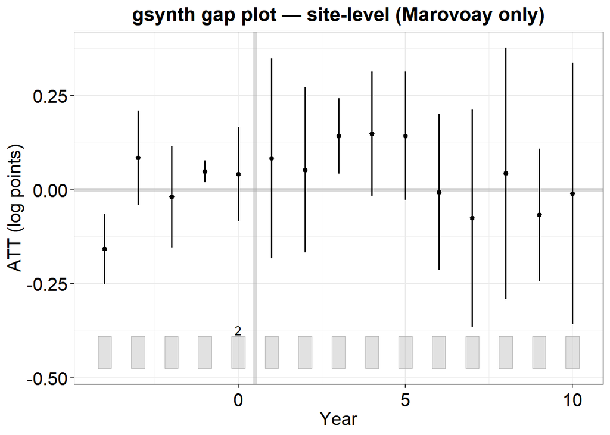

```r
run_gsynth_site <- function(data) {
  d <- data |>
    filter(!is.na(ln_revtot_w))
  suppressWarnings(
    gsynth(ln_revtot_w ~ treatment,
           data      = d,
           index     = c("site_id", "year"),
           se        = TRUE, inference = "nonparametric", nboots = 200,
           r = 0, CV = FALSE, force = "two-way",
           parallel  = FALSE, min.T0 = 4, seed = 2139)
  )
}

gs_maro <- tryCatch(run_gsynth_site(panel_site_maro), error = function(e) NULL)

if (!is.null(gs_maro))
  plot(gs_maro, type = "gap",
       main = "gsynth gap plot — site-level (Marovoay only)",
       ylab = "ATT (log points)", xlab = "Year")
```

## 7 Synthesis: All Estimates

```r
att_row <- function(method, spec, estimand, att, se, ci_lo = NA, ci_hi = NA) {
  tibble(Method = method, Specification = spec, Estimand = estimand,
         ATT = att, SE = se, CI_lo = ci_lo, CI_hi = ci_hi)
}

# RC DiD
rc_att  <- tryCatch(coef(fit_rc_revtot)[["treatment"]],  error = function(e) NA_real_)
rc_se   <- tryCatch(se(fit_rc_revtot)[["treatment"]],    error = function(e) NA_real_)

# RC DiD (with HH size control)
rcc_att <- tryCatch(coef(fit_rc_cov)[["treatment"]],     error = function(e) NA_real_)
rcc_se  <- tryCatch(se(fit_rc_cov)[["treatment"]],       error = function(e) NA_real_)

# Long-run DiD (Marovoay only)
lr_att  <- tryCatch(coef(fit_lr)[["did_lr"]],            error = function(e) NA_real_)
lr_se   <- tryCatch(se(fit_lr)[["did_lr"]],              error = function(e) NA_real_)

# Long-run DiD (Marovoay + Alaotra)
lre_att <- tryCatch(coef(fit_lr_ext)[["did_lr"]],        error = function(e) NA_real_)
lre_se  <- tryCatch(se(fit_lr_ext)[["did_lr"]],          error = function(e) NA_real_)

# gsynth site-level
gs_att  <- tryCatch(mean(gs_maro$att.avg, na.rm = TRUE), error = function(e) NA_real_)
gs_se   <- tryCatch(sd(as.vector(gs_maro$att.avg.boot), na.rm = TRUE), error = function(e) NA_real_)

bind_rows(
  att_row("RC DiD",           "Site + year FE",             "Medium-run ATT (1999–2014)", rc_att,  rc_se,
          rc_att  - 1.96 * rc_se,  rc_att  + 1.96 * rc_se),
  att_row("RC DiD + HH size", "Site + year FE + n_membres", "Medium-run ATT (1999–2014)", rcc_att, rcc_se,
          rcc_att - 1.96 * rcc_se, rcc_att + 1.96 * rcc_se),
  att_row("Long-run DiD (Maro)",  "Site + period FE, 4 sites", "Long-run ATT (1999–2002 vs 2025)",
          lr_att,  lr_se,  lr_att  - 1.96 * lr_se,  lr_att  + 1.96 * lr_se),
  att_row("Long-run DiD (Maro+Al)", "Site + period FE, 7 sites", "Long-run ATT (1999–2002 vs 2025)",
          lre_att, lre_se, lre_att - 1.96 * lre_se, lre_att + 1.96 * lre_se),
  att_row("gsynth (site)",    "IFE, nonparam bootstrap",    "Medium-run ATT (1999–2014)", gs_att, gs_se,
          gs_att - 1.96 * gs_se, gs_att + 1.96 * gs_se)
) |>
  gt() |>
  fmt_number(columns = c(ATT, SE, CI_lo, CI_hi), decimals = 3) |>
  cols_label(Method = "Estimator", Specification = "FE structure",
             Estimand = "Estimand", ATT = "ATT", SE = "SE",
             CI_lo = "95% CI lo", CI_hi = "95% CI hi") |>
  tab_style(style = list(cell_text(weight = "bold"), cell_fill(color = "#DCDCDC")),
            locations = cells_column_labels()) |>
  tab_style(style = cell_fill(color = "#FFF3CD"),
            locations = cells_body(rows = Method == "Long-run DiD")) |>
  tab_source_note(md(
    "Outcome: log winsorised total income. CIs: 1.96 × cluster SE (4 clusters).
    gsynth SE via 200 nonparametric bootstrap draws.
    Long-run DiD captures 2002 + 2015 treatment effects jointly.
    See permutation tests (§4.4, §5.3) for finite-sample p-values."
  ))
```

All ATT estimates — log total income, Marovoay–Ankarafantsika

| Estimator | FE structure | Estimand | ATT | SE | 95% CI lo | 95% CI hi |
| --- | --- | --- | --- | --- | --- | --- |
| RC DiD | Site + year FE | Medium-run ATT (1999–2014) | 0.007 | 0.135 | −0.257 | 0.272 |
| RC DiD + HH size | Site + year FE + n_membres | Medium-run ATT (1999–2014) | 0.037 | 0.128 | −0.214 | 0.289 |
| Long-run DiD (Maro) | Site + period FE, 4 sites | Long-run ATT (1999–2002 vs 2025) | −0.425 | 0.178 | −0.774 | −0.076 |
| Long-run DiD (Maro+Al) | Site + period FE, 7 sites | Long-run ATT (1999–2002 vs 2025) | −0.753 | 0.217 | −1.178 | −0.328 |
| gsynth (site) | IFE, nonparam bootstrap | Medium-run ATT (1999–2014) | 0.046 | 0.111 | −0.171 | 0.262 |

Outcome: log winsorised total income. CIs: 1.96 × cluster SE (4 clusters). gsynth SE via 200 nonparametric bootstrap draws. Long-run DiD captures 2002 + 2015 treatment effects jointly. See permutation tests (§4.4, §5.3) for finite-sample p-values.

## 8 Spatial RDD: Data Availability Assessment

The most powerful identification strategy would be a spatial RDD using distance from the Ankarafantsika PA boundary as the running variable. The 2025 survey collected GPS coordinates for all survey sites.

```r
tribble(
  ~`Data layer`, ~`Available?`, ~`Source`, ~`Implication`,
  "Fokontany centroid GPS", "Yes",
    "`01_description.qmd` (hardcoded tribble)",
    "Site-level distance to PA computable; too coarse for RDD",
  "Hamlet (hameau) GPS", "Yes",
    "`Coordonnées_GPS_OR_Alaotra_Marovoay_2025.ods`",
    "4–8 hamlets per site; still too coarse for within-site RDD",
  "Individual household GPS", "Unknown",
    "Would need field GPS from `res_deb.dta` or separate file",
    "Required for boundary-discontinuity RDD",
  "PA boundary polygon", "Yes",
    "`data/ankarafantsika_protected_area.geojson`",
    "Running variable = distance to boundary (metres)"
) |>
  gt() |>
  tab_style(style = list(cell_text(weight = "bold"), cell_fill(color = "#DCDCDC")),
            locations = cells_column_labels()) |>
  tab_style(style = cell_fill(color = "#D4EDDA"),
            locations = cells_body(rows = `Available?` == "Yes")) |>
  tab_style(style = cell_fill(color = "#FFF3CD"),
            locations = cells_body(rows = `Available?` == "Unknown")) |>
  tab_source_note(md(
    "The hamlet-level GPS centroids give **4–8 points per site** — not enough for
    a smooth running-variable RDD. Household GPS would give ~120 observations per
    site in 2025, enabling a local linear RDD in the 0–15 km bandwidth around the
    PA boundary. If individual GPS was recorded in `res_deb.dta` (or a companion
    GPS file), it should be checked before concluding RDD is infeasible."
  ))
```

GPS data availability and spatial RDD feasibility

| Data layer | Available? | Source | Implication |
| --- | --- | --- | --- |
| Fokontany centroid GPS | Yes | `01_description.qmd` (hardcoded tribble) | Site-level distance to PA computable; too coarse for RDD |
| Hamlet (hameau) GPS | Yes | `Coordonnées_GPS_OR_Alaotra_Marovoay_2025.ods` | 4–8 hamlets per site; still too coarse for within-site RDD |
| Individual household GPS | Unknown | Would need field GPS from `res_deb.dta` or separate file | Required for boundary-discontinuity RDD |
| PA boundary polygon | Yes | `data/ankarafantsika_protected_area.geojson` | Running variable = distance to boundary (metres) |

The hamlet-level GPS centroids give **4–8 points per site** — not enough for a smooth running-variable RDD. Household GPS would give ~120 observations per site in 2025, enabling a local linear RDD in the 0–15 km bandwidth around the PA boundary. If individual GPS was recorded in `res_deb.dta` (or a companion GPS file), it should be checked before concluding RDD is infeasible.

## 9 Interpretation

The rotating-panel structure of the Madagascar ROS data constrains but does not preclude a credible impact evaluation. The key implications are:

1. **The site is the effective unit of observation** for treatment assignment. Any specification — whether household-level repeated cross-sections or site-level aggregation — ultimately clusters inference at the 4-site level. This hard ceiling on statistical power is intrinsic to the design.
2. **The RC DiD gains efficiency** relative to the site-level aggregate by using the full within-site variance in outcomes, not just site means. The point estimate should be identical to the site-level TWFE; the SE should be narrower if within-site variance is informative. With only $G = 4$ sites, conventional clustered SEs and the wild cluster bootstrap both undercover; the exact permutation test (§4.4) is the appropriate inference tool.
3. **The long-run DiD is the most policy-relevant estimate**: it captures the 23-year compound effect of the PA regime on household incomes, using a clean pre-treatment baseline (1999–2002) and a fresh 2025 cross-section. It is immune to the panel-gap problem and the `j5` instability issue. The extended specification including Alaotra controls (7 sites) reduces the minimum permutation p-value from 0.333 to 0.095, making statistically detectable effects possible for the first time in this design.
4. **Spatial RDD remains the priority extension**: if household-level GPS is embedded in `res_deb.dta` or a companion file, a boundary-discontinuity design in the 2025 cross-section would provide the sharpest identification and is entirely independent of the panel attrition problem.

## References

- Chabé-Ferret, S. *et al.* (2024). The Madagascar Rural Observatory Survey (1995–2015). *Scientific Data* 11: 1085. https://doi.org/10.1038/s41597-024-03879-9
- MacKinnon, J.G. & Webb, M.D. (2018). The wild bootstrap for few (treated) clusters. *Econometrics Journal* 21(2): 114–135.
- Callaway, B. & Sant’Anna, P. (2020). Difference-in-differences with multiple time periods. *Journal of Econometrics* 225(2): 200–230.